# Отчет по лабораторной работе №1

Подготовка лабораторного стенда

Виноградова М.А

Российский университет дружбы народов, Москва, Россия

# Информация

## Докладчик

- Виноградова Мария Андреевна
- студентка НПИбд-02-24
- номер студ. билета 1132240691
- Российский университет дружбы народов
- 1132240691@pfur.ru
- https://github.com/mavinogradova/study_2025-2026_os2

# Цель работы

Приобретение практических навыков установки Rocky Linux на виртуальную машину с помощью инструмента Vagrant.

# Задание

1. Сформировать box-файл с дистрибутивом Rocky Linux для VirtualBox.
2. Запустить виртуальные машины сервера и клиента и убедиться в их работоспособности.
3. Внести изменения в настройки загрузки образов виртуальных машин server и client, добавив пользователя с правами администратора и изменив названия хостов.
4. Скопировать необходимые для работы с Vagrant файлы и box-файлы виртуальных машин на внешний носитель.

# Выполнение лабораторной работы

# Подготовка рабочего каталога

## Создаём каталог для проекта. В ОС Windows — `D:\work\mavinogradova\packer` и `D:\work\mavinogradova\vagrant`.

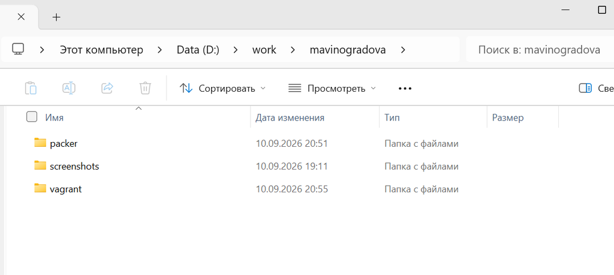

Структура рабочего каталога

## В подкаталоге `packer` размещаем образ Rocky Linux (`Rocky-10.2-x86_64-minimal.iso`).

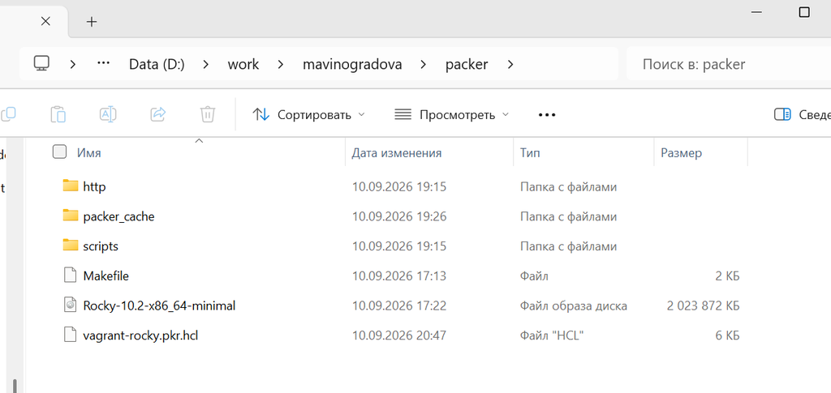

Содержимое каталога packer

## В подкаталоге `vagrant` размещаем `Vagrantfile` и `Makefile`.

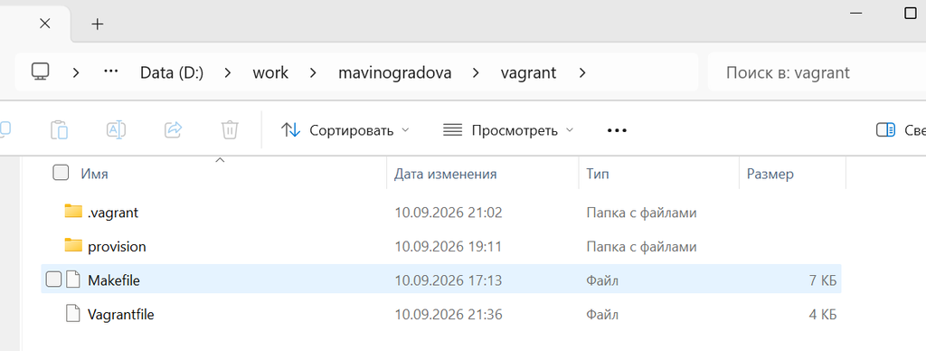

Содержимое каталога vagrant

## Создаём каталог `provision` с подкаталогами `default`, `server` и `client`.

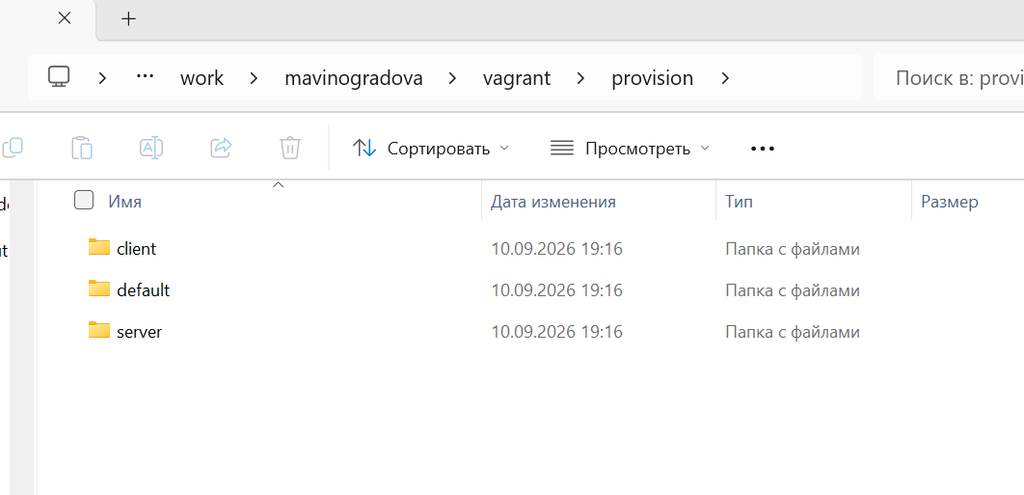

Содержимое каталога provision

# Настройка скриптов провижининга

## Скрипт `01-user.sh` — в переменной `username` указываем `mavinogradova`.

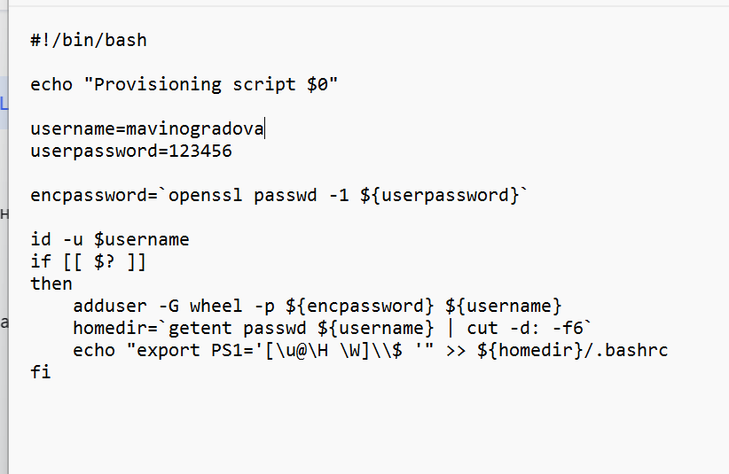

Скрипт 01-user.sh

## Скрипт `01-hostname.sh` — также указываем `mavinogradova`.

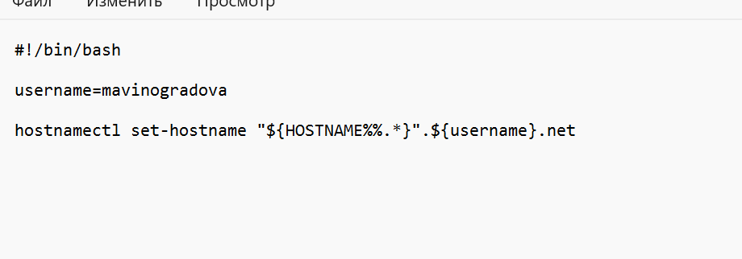

Скрипт 01-hostname.sh

# Конфигурационный файл Vagrantfile

## Блок `## Common configuration` — инструкции по применению скриптов провижининга.

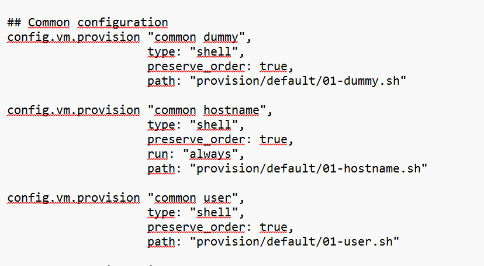

Vagrantfile — common configuration

## Блок `## Server configuration` — имя box-файла, hostname, SSH, сеть.

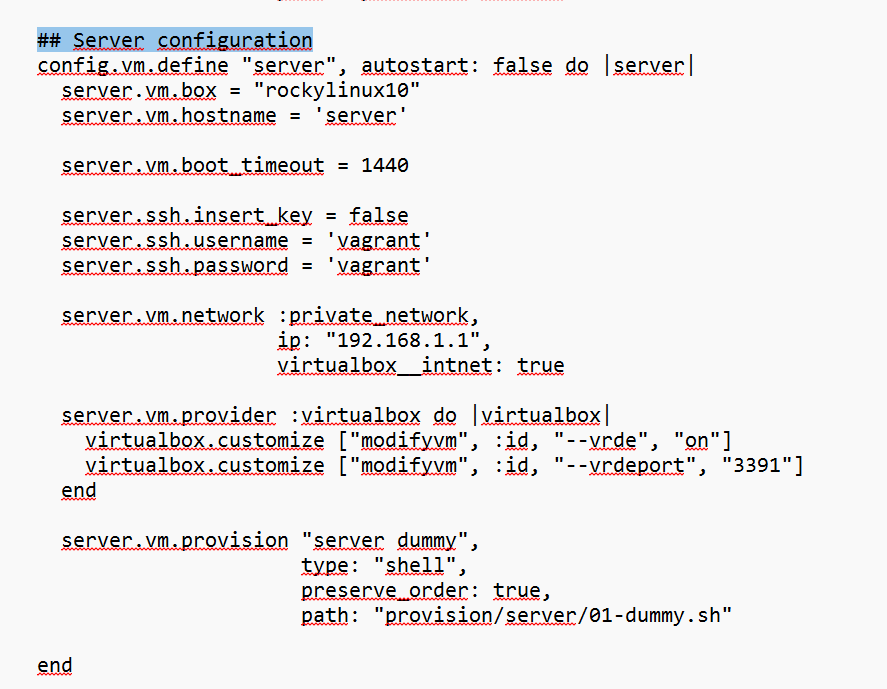

Vagrantfile — server configuration

## Блок `## Client configuration`.

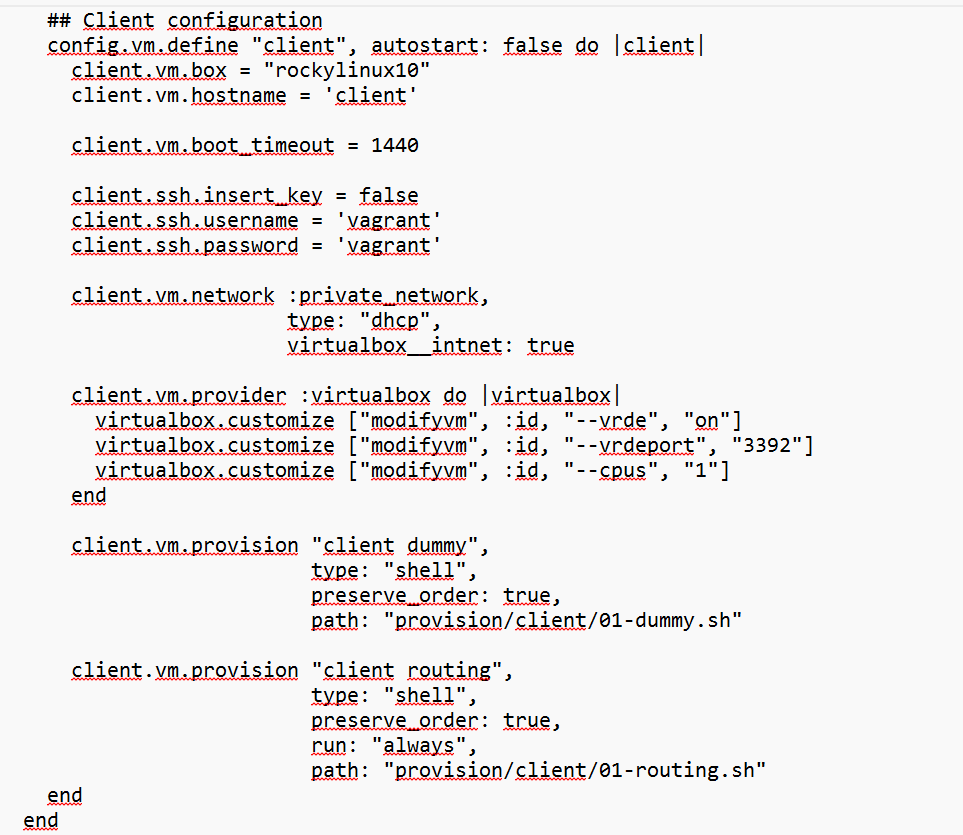

Vagrantfile — client configuration

# HCL-файл настроек виртуальной машины

## Файл `vagrant-rocky.pkr.hcl` — версия дистрибутива, хэш, имя ISO.

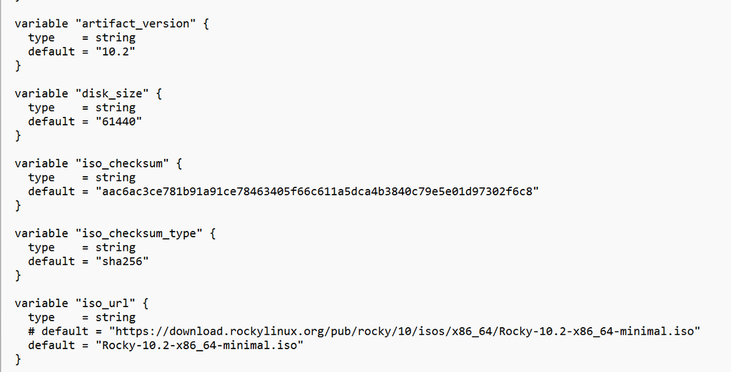

vagrant-rocky.pkr.hcl — переменные

## Проверяем контрольную сумму ISO-образа Rocky Linux 10.2.

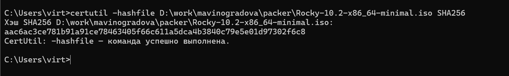

certutil — хэш ISO

## Значение `iso_checksum` в hcl совпадает с полученным хэшем.

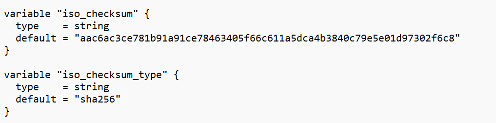

hcl — iso_checksum

# Сборка box-файла с помощью Packer

## Инициализация Packer.

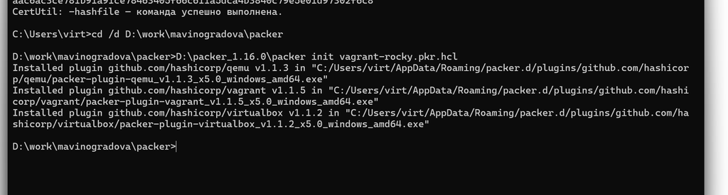

packer init

## Запуск сборки box-файла.

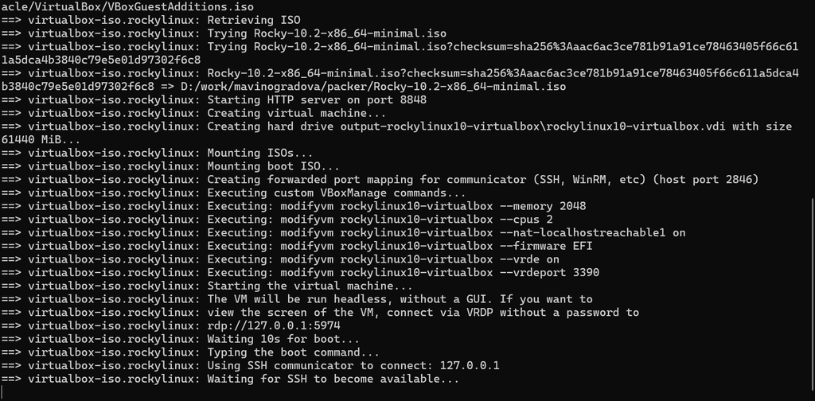

packer build — начало

## Автоматическое развёртывание дистрибутива (Anaconda).

[figure not shown]

Anaconda — установка

# Регистрация box-файла в Vagrant

## Регистрация образа виртуальной машины.

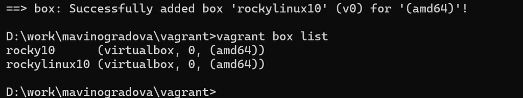

vagrant box add

# Запуск виртуальной машины Server

## Запуск сервера.

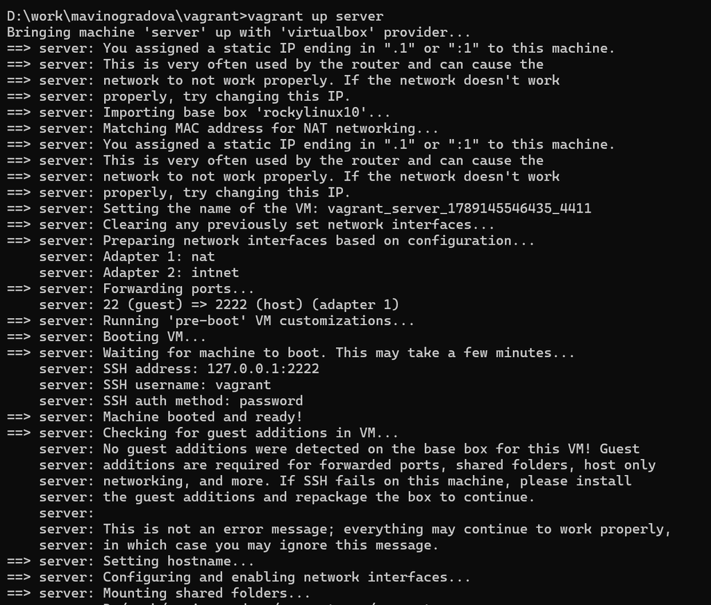

vagrant up server

## Виртуальная машина `vagrant_server_...` в VirtualBox — работает.

[figure not shown]

VirtualBox — server

# Запуск виртуальной машины Client

## Запуск клиента.

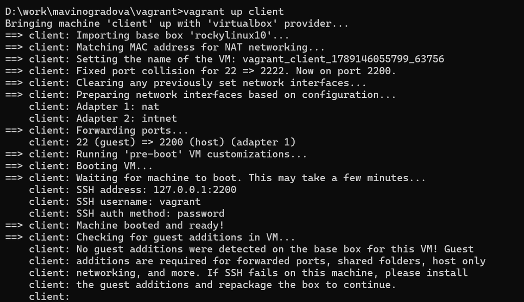

vagrant up client

## Обе виртуальные машины — server и client — в состоянии «Работает».

[figure not shown]

VirtualBox — обе ВМ

# Проверка работоспособности стенда

## Проверяем состояние виртуальных машин.

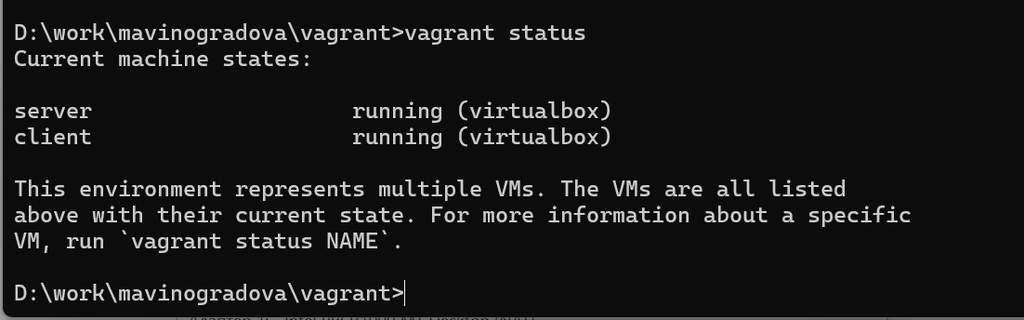

vagrant status

## Подключаемся к серверу.

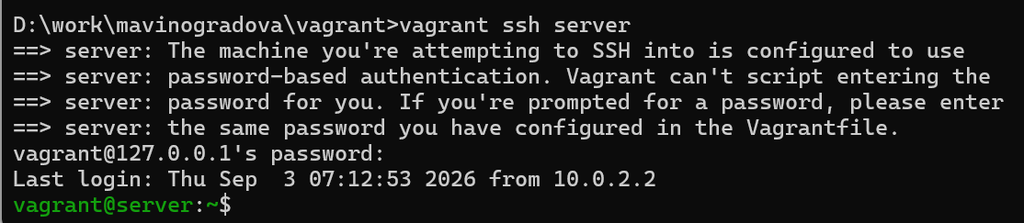

vagrant ssh server

## Переходим к пользователю `mavinogradova`.

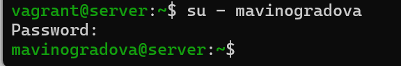

Приглашение на сервере

## Подключаемся к клиенту.

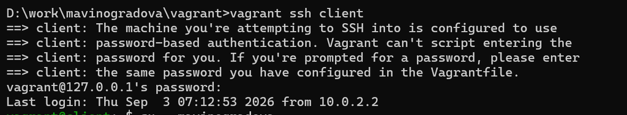

vagrant ssh client

## Переходим к пользователю `mavinogradova` на клиенте.

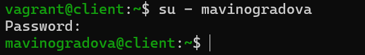

Приглашение на клиенте

# Выключение виртуальных машин

## Выключаем обе виртуальные машины.

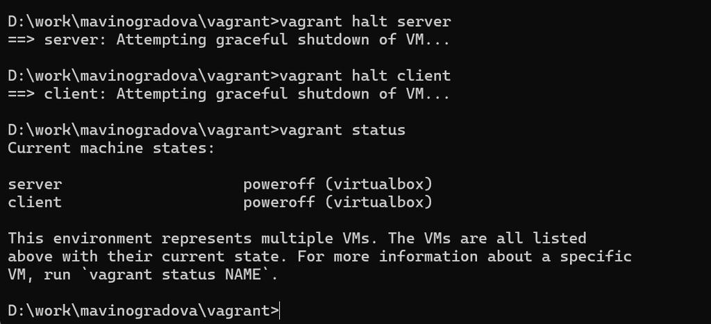

ВМ выключены

# Внесение изменений в настройки окружения

## Фиксируем изменения для server.

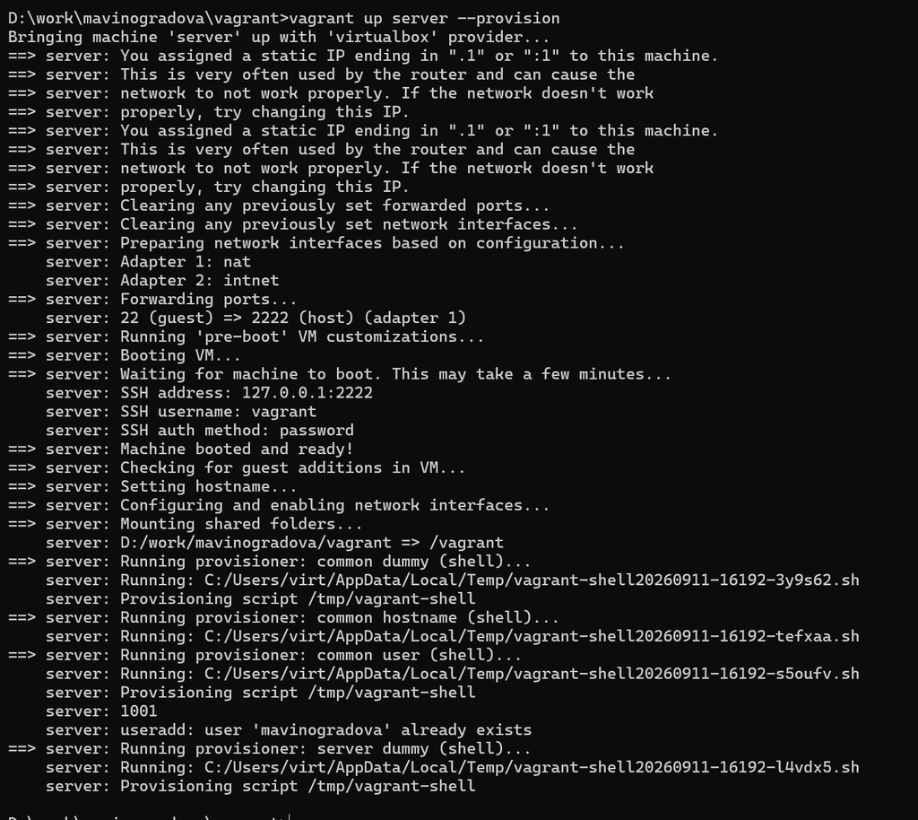

vagrant up server –provision

## Фиксируем изменения для client.

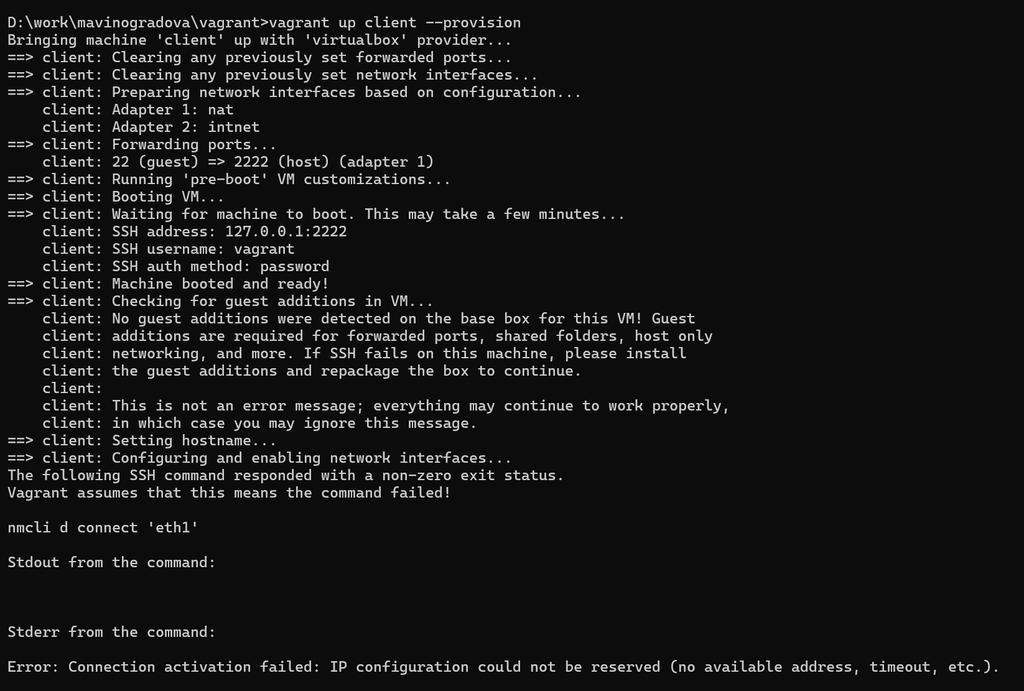

vagrant up client –provision

# Выводы

Приобретены практические навыки установки Rocky Linux на виртуальную машину с помощью Vagrant. Освоены создание и настройка `Vagrantfile`, работа с box-файлами, развёртывание стенда из двух машин (server и client), настройка окружения с помощью скриптов провижининга.